# Predicting the price of Apartments in Dubai

Nafis Ahmed Munim

6/1/2021

## Abstract

We have a dataset of 500 apartments in Dubai which is our training dataset and we also have a Dataset with 500 other apartments in dubai which doesn’t include their price in the dataset we try to the best model from our training data to predict the price of the apartments in the test data . We use different techniques to find the best model and do the best prediction for the apartments in the test data. We use root mean square errors and root mean square predicted errors to find our best model which doesn’t overfit and gives the best possible prediction from the training dataset. We found that best model to predict the price best in this project.

## Introduction

We use the training data to predict the prices for the test data and we have 38 variables in our training dataset. We try to analyze the important variables which contribute to the price of the apartments. We will try to build a model with price as our response variable and other explanatory varibales from the data. We are building almost 8 models and from that we will do cross validation and see which model works the best for the test dataset and predicts the price of the apartments the best. We have also done a bit of varibale engineering to combine some of the varibales which could make change in the response variable and as there are a lot of variables in the datset we try to combine varibales which seemed to be same categorized.

## Exploratory Analysis

We can see here that both the test and the train datset has the same amount of rows and the same amount of variables and also we can see that there are no values for the price in the test data and that’s why we will predict the prices. Also we can see that there are are total 8 numerical variable, 2 character and 28 logical variable in the train datset and also we can see that the test dataset has the same variables abut some of the logical variables used in the train dataset is as a character variable in the test dataset. As we will primarily use the training data for the model that shouldn’t be a concern now. Also we can see that the price variable has all the values missing as we are predicting these values. Other than that there are no more missing values for any of the variables for the training or the test dataset which is a great thing to start.

```
##        X                id          neighborhood          latitude
##  Min.   :  17.0   Min.   :6526808   Length:500         Min.   :24.93
##  1st Qu.: 451.5   1st Qu.:7557599   Class :character   1st Qu.:25.07
##  Median : 926.0   Median :7631852   Mode  :character   Median :25.09
##  Mean   : 934.1   Mean   :7582320                      Mean   :25.12
##  3rd Qu.:1419.2   3rd Qu.:7671411                      3rd Qu.:25.19
##  Max.   :1862.0   Max.   :7706591                      Max.   :25.24
##    longitude      size_in_sqft    no_of_bedrooms  no_of_bathrooms
##  Min.   :55.11   Min.   : 321.0   Min.   :0.000   Min.   :1.000
##  1st Qu.:55.15   1st Qu.: 821.8   1st Qu.:1.000   1st Qu.:2.000
##  Median :55.21   Median :1271.0   Median :2.000   Median :2.000
##  Mean   :55.21   Mean   :1349.3   Mean   :1.768   Mean   :2.488
##  3rd Qu.:55.27   3rd Qu.:1669.5   3rd Qu.:2.000   3rd Qu.:3.000
##  Max.   :55.44   Max.   :5757.0   Max.   :4.000   Max.   :5.000
##    quality          maid_room       unfurnished      balcony
##  Length:500         Mode :logical   Mode :logical   Mode :logical
##  Class :character   FALSE:426       FALSE:164       FALSE:144
##  Mode  :character   TRUE :74        TRUE :336       TRUE :356
##
##
##
##  barbecue_area   built_in_wardrobes central_ac      childrens_play_area
##  Mode :logical   Mode :logical      Mode :logical   Mode :logical
##  FALSE:423       FALSE:144          FALSE:167       FALSE:334
##  TRUE :77        TRUE :356          TRUE :333       TRUE :166
##
##
##
##  childrens_pool  concierge       covered_parking kitchen_appliances
##  Mode :logical   Mode :logical   Mode :logical   Mode :logical
##  FALSE:451       FALSE:310       FALSE:196       FALSE:332
##  TRUE :49        TRUE :190       TRUE :304       TRUE :168
##
##
##
##  lobby_in_building maid_service    networked       pets_allowed
##  Mode :logical     Mode :logical   Mode :logical   Mode :logical
##  FALSE:445         FALSE:464       FALSE:470       FALSE:353
##  TRUE :55          TRUE :36        TRUE :30        TRUE :147
##
```

[output cut: 15 more lines]

```
##
##    study         vastu_compliant view_of_landmark view_of_water
##  Mode :logical   Mode :logical   Mode :logical    Mode :logical
##  FALSE:450       FALSE:475       FALSE:393        FALSE:324
##  TRUE :50        TRUE :25        TRUE :107        TRUE :176
##
##
##
##  walk_in_closet      price
##  Mode :logical   Min.   : 230000
##  FALSE:424       1st Qu.: 860500
##  TRUE :76        Median :1400000
##                  Mean   :1717926
##                  3rd Qu.:2110000
##                  Max.   :9999999
```

```
##        X                id          neighborhood          latitude
##  Min.   :   1.0   Min.   :5528049   Length:500         Min.   :24.94
##  1st Qu.: 483.8   1st Qu.:7570816   Class :character   1st Qu.:25.07
##  Median : 942.0   Median :7635060   Mode  :character   Median :25.09
##  Mean   : 941.0   Mean   :7577455                      Mean   :25.12
##  3rd Qu.:1391.2   3rd Qu.:7670114                      3rd Qu.:25.19
##  Max.   :1856.0   Max.   :7705293                      Max.   :25.27
##    longitude      size_in_sqft    no_of_bedrooms  no_of_bathrooms
##  Min.   :55.07   Min.   : 296.0   Min.   :0.000   Min.   :1.000
##  1st Qu.:55.15   1st Qu.: 836.2   1st Qu.:1.000   1st Qu.:2.000
##  Median :55.21   Median :1208.5   Median :2.000   Median :2.000
##  Mean   :55.21   Mean   :1324.2   Mean   :1.746   Mean   :2.424
##  3rd Qu.:55.27   3rd Qu.:1670.5   3rd Qu.:2.000   3rd Qu.:3.000
##  Max.   :55.44   Max.   :4526.0   Max.   :5.000   Max.   :6.000
##    quality           maid_room         unfurnished          balcony
##  Length:500         Length:500         Length:500         Length:500
##  Class :character   Class :character   Class :character   Class :character
##  Mode  :character   Mode  :character   Mode  :character   Mode  :character
##
##
##
##  barbecue_area      built_in_wardrobes  central_ac        childrens_play_area
##  Length:500         Length:500         Length:500         Length:500
##  Class :character   Class :character   Class :character   Class :character
##  Mode  :character   Mode  :character   Mode  :character   Mode  :character
##
##
##
##  childrens_pool      concierge         covered_parking    kitchen_appliances
##  Length:500         Length:500         Length:500         Length:500
##  Class :character   Class :character   Class :character   Class :character
##  Mode  :character   Mode  :character   Mode  :character   Mode  :character
##
##
##
##  lobby_in_building  maid_service        networked         pets_allowed
##  Length:500         Length:500         Length:500         Length:500
##  Class :character   Class :character   Class :character   Class :character
##  Mode  :character   Mode  :character   Mode  :character   Mode  :character
##
```

[output cut: 15 more lines]

```
##
##     study           vastu_compliant    view_of_landmark   view_of_water
##  Length:500         Length:500         Length:500         Length:500
##  Class :character   Class :character   Class :character   Class :character
##  Mode  :character   Mode  :character   Mode  :character   Mode  :character
##
##
##
##  walk_in_closet      price
##  Length:500         Mode:logical
##  Class :character   NA's:500
##  Mode  :character
##
##
##
```

Data summary

| Name | Train |
| --- | --- |
| Number of rows | 500 |
| Number of columns | 38 |
| _______________________ |  |
| Column type frequency: |  |
| character | 2 |
| logical | 28 |
| numeric | 8 |
| ________________________ |  |
| Group variables | None |

**Variable type: character**

| skim_variable | n_missing | complete_rate | min | max | empty | n_unique | whitespace |
| --- | --- | --- | --- | --- | --- | --- | --- |
| neighborhood | 0 | 1 | 4 | 33 | 0 | 43 | 0 |
| quality | 0 | 1 | 3 | 6 | 0 | 4 | 0 |

**Variable type: logical**

| skim_variable | n_missing | complete_rate | mean | count |
| --- | --- | --- | --- | --- |
| maid_room | 0 | 1 | 0.15 | FAL: 426, TRU: 74 |
| unfurnished | 0 | 1 | 0.67 | TRU: 336, FAL: 164 |
| balcony | 0 | 1 | 0.71 | TRU: 356, FAL: 144 |
| barbecue_area | 0 | 1 | 0.15 | FAL: 423, TRU: 77 |
| built_in_wardrobes | 0 | 1 | 0.71 | TRU: 356, FAL: 144 |
| central_ac | 0 | 1 | 0.67 | TRU: 333, FAL: 167 |
| childrens_play_area | 0 | 1 | 0.33 | FAL: 334, TRU: 166 |
| childrens_pool | 0 | 1 | 0.10 | FAL: 451, TRU: 49 |
| concierge | 0 | 1 | 0.38 | FAL: 310, TRU: 190 |
| covered_parking | 0 | 1 | 0.61 | TRU: 304, FAL: 196 |
| kitchen_appliances | 0 | 1 | 0.34 | FAL: 332, TRU: 168 |
| lobby_in_building | 0 | 1 | 0.11 | FAL: 445, TRU: 55 |
| maid_service | 0 | 1 | 0.07 | FAL: 464, TRU: 36 |
| networked | 0 | 1 | 0.06 | FAL: 470, TRU: 30 |
| pets_allowed | 0 | 1 | 0.29 | FAL: 353, TRU: 147 |
| private_garden | 0 | 1 | 0.01 | FAL: 494, TRU: 6 |
| private_gym | 0 | 1 | 0.01 | FAL: 497, TRU: 3 |
| private_jacuzzi | 0 | 1 | 0.06 | FAL: 472, TRU: 28 |
| private_pool | 0 | 1 | 0.05 | FAL: 477, TRU: 23 |
| security | 0 | 1 | 0.35 | FAL: 325, TRU: 175 |
| shared_gym | 0 | 1 | 0.70 | TRU: 350, FAL: 150 |
| shared_pool | 0 | 1 | 0.77 | TRU: 383, FAL: 117 |
| shared_spa | 0 | 1 | 0.09 | FAL: 456, TRU: 44 |
| study | 0 | 1 | 0.10 | FAL: 450, TRU: 50 |
| vastu_compliant | 0 | 1 | 0.05 | FAL: 475, TRU: 25 |
| view_of_landmark | 0 | 1 | 0.21 | FAL: 393, TRU: 107 |
| view_of_water | 0 | 1 | 0.35 | FAL: 324, TRU: 176 |
| walk_in_closet | 0 | 1 | 0.15 | FAL: 424, TRU: 76 |

**Variable type: numeric**

Data summary

| skim_variable | n_missing | complete_rate | mean | sd | p0 | p25 | p50 | p75 | p100 | hist |
| --- | --- | --- | --- | --- | --- | --- | --- | --- | --- | --- |
| X | 0 | 1 | 934.08 | 545.08 | 17.00 | 451.50 | 926.00 | 1419.25 | 1862.00 | ▇▇▇▇▇ |
| id | 0 | 1 | 7582320.39 | 152651.74 | 6526808.00 | 7557599.00 | 7631852.00 | 7671410.75 | 7706591.00 | ▁▁▁▁▇ |
| latitude | 0 | 1 | 25.12 | 0.06 | 24.93 | 25.07 | 25.09 | 25.19 | 25.24 | ▁▃▇▁▆ |
| longitude | 0 | 1 | 55.21 | 0.07 | 55.11 | 55.15 | 55.21 | 55.27 | 55.44 | ▇▃▇▁▁ |
| size_in_sqft | 0 | 1 | 1349.34 | 704.90 | 321.00 | 821.75 | 1271.00 | 1669.50 | 5757.00 | ▇▅▁▁▁ |
| no_of_bedrooms | 0 | 1 | 1.77 | 0.89 | 0.00 | 1.00 | 2.00 | 2.00 | 4.00 | ▁▆▇▃▁ |
| no_of_bathrooms | 0 | 1 | 2.49 | 1.00 | 1.00 | 2.00 | 2.00 | 3.00 | 5.00 | ▃▇▆▃▁ |
| price | 0 | 1 | 1717925.78 | 1244438.48 | 230000.00 | 860500.00 | 1400000.00 | 2110000.00 | 9999999.00 | ▇▂▁▁▁ |

| Name | Test |
| --- | --- |
| Number of rows | 500 |
| Number of columns | 38 |
| _______________________ |  |
| Column type frequency: |  |
| character | 30 |
| logical | 1 |
| numeric | 7 |
| ________________________ |  |
| Group variables | None |

**Variable type: character**

| skim_variable | n_missing | complete_rate | min | max | empty | n_unique | whitespace |
| --- | --- | --- | --- | --- | --- | --- | --- |
| neighborhood | 0 | 1 | 4 | 33 | 0 | 51 | 0 |
| quality | 0 | 1 | 3 | 6 | 0 | 4 | 0 |
| maid_room | 0 | 1 | 4 | 5 | 0 | 2 | 0 |
| unfurnished | 0 | 1 | 4 | 5 | 0 | 2 | 0 |
| balcony | 0 | 1 | 4 | 5 | 0 | 2 | 0 |
| barbecue_area | 0 | 1 | 4 | 5 | 0 | 2 | 0 |
| built_in_wardrobes | 0 | 1 | 4 | 5 | 0 | 2 | 0 |
| central_ac | 0 | 1 | 4 | 5 | 0 | 2 | 0 |
| childrens_play_area | 0 | 1 | 4 | 5 | 0 | 2 | 0 |
| childrens_pool | 0 | 1 | 4 | 5 | 0 | 2 | 0 |
| concierge | 0 | 1 | 4 | 5 | 0 | 2 | 0 |
| covered_parking | 0 | 1 | 4 | 5 | 0 | 2 | 0 |
| kitchen_appliances | 0 | 1 | 4 | 5 | 0 | 2 | 0 |
| lobby_in_building | 0 | 1 | 4 | 5 | 0 | 2 | 0 |
| maid_service | 0 | 1 | 4 | 5 | 0 | 2 | 0 |
| networked | 0 | 1 | 4 | 5 | 0 | 2 | 0 |
| pets_allowed | 0 | 1 | 4 | 5 | 0 | 2 | 0 |
| private_garden | 0 | 1 | 4 | 5 | 0 | 2 | 0 |
| private_gym | 0 | 1 | 4 | 5 | 0 | 2 | 0 |
| private_jacuzzi | 0 | 1 | 4 | 5 | 0 | 2 | 0 |
| private_pool | 0 | 1 | 4 | 5 | 0 | 2 | 0 |
| security | 0 | 1 | 4 | 5 | 0 | 2 | 0 |
| shared_gym | 0 | 1 | 4 | 5 | 0 | 2 | 0 |
| shared_pool | 0 | 1 | 4 | 5 | 0 | 2 | 0 |
| shared_spa | 0 | 1 | 4 | 5 | 0 | 2 | 0 |
| study | 0 | 1 | 4 | 5 | 0 | 2 | 0 |
| vastu_compliant | 0 | 1 | 4 | 5 | 0 | 2 | 0 |
| view_of_landmark | 0 | 1 | 4 | 5 | 0 | 2 | 0 |
| view_of_water | 0 | 1 | 4 | 5 | 0 | 2 | 0 |
| walk_in_closet | 0 | 1 | 4 | 5 | 0 | 2 | 0 |

**Variable type: logical**

| skim_variable | n_missing | complete_rate | mean | count |
| --- | --- | --- | --- | --- |
| price | 500 | 0 | NaN | : |

**Variable type: numeric**

| skim_variable | n_missing | complete_rate | mean | sd | p0 | p25 | p50 | p75 | p100 | hist |
| --- | --- | --- | --- | --- | --- | --- | --- | --- | --- | --- |
| X | 0 | 1 | 941.00 | 528.06 | 1.00 | 483.75 | 942.00 | 1391.25 | 1856.00 | ▆▇▇▇▇ |
| id | 0 | 1 | 7577454.86 | 196050.85 | 5528049.00 | 7570815.75 | 7635059.50 | 7670113.75 | 7705293.00 | ▁▁▁▁▇ |
| latitude | 0 | 1 | 25.12 | 0.06 | 24.94 | 25.07 | 25.09 | 25.19 | 25.27 | ▁▆▇▅▂ |
| longitude | 0 | 1 | 55.21 | 0.07 | 55.07 | 55.15 | 55.21 | 55.27 | 55.44 | ▅▇▇▁▁ |
| size_in_sqft | 0 | 1 | 1324.22 | 644.35 | 296.00 | 836.25 | 1208.50 | 1670.50 | 4526.00 | ▇▇▂▁▁ |
| no_of_bedrooms | 0 | 1 | 1.75 | 0.91 | 0.00 | 1.00 | 2.00 | 2.00 | 5.00 | ▇▇▃▁▁ |
| no_of_bathrooms | 0 | 1 | 2.42 | 1.00 | 1.00 | 2.00 | 2.00 | 3.00 | 6.00 | ▇▃▂▁▁ |

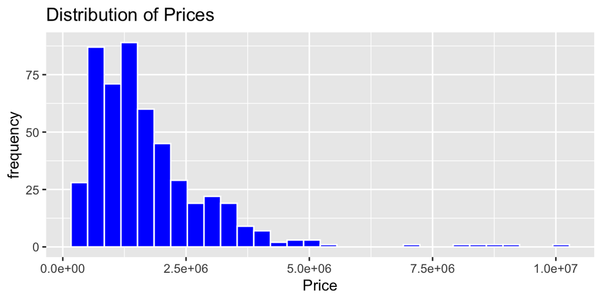

From the graph of distribution of prices for the 500 apartments we can see that there are a lot of outliers in the right which means there are some apartments which are very overpriced and other than the outliers the graph looks fine to work with

[figure not shown]

Price Distribution by Neighborhood

Now we have tried to graph the prices of the apartments according to the neighborhood and we can see that there are a lot of neighborhoods in the city and we can see that the price differs a lot by neighborhood as we can see from the graph that the median price of the appartments differs a lot according to the neigborhoods they are situated in. We have created a graph below with the mean price of the apartments according to the neighborhoods which shows that there might be a relationship between the neighborhood and the price ans we should add this in the model. But we have to do some varibale or feature engineering to the variable as htere are a lot of neighborhoods which have a very little apartments and that might be a problem while predicting in the test data or doing cross validation. We will do that later on in the project.

Average Price by Neighborhood

| neighborhood | Mean_Price | SD_Price | N |
| --- | --- | --- | --- |
| Al Barari | 2816666.7 | 525198.38 | 3 |
| Al Barsha | 778000.0 | NA | 1 |
| Al Furjan | 722250.0 | 97109.47 | 4 |
| Al Kifaf | 2073388.5 | 37634.34 | 2 |
| Al Sufouh | 1313000.0 | 539450.65 | 3 |
| Arjan | 845000.0 | NA | 1 |
| Bluewaters | 2665000.0 | 374766.59 | 2 |
| Business Bay | 1432006.0 | 629372.61 | 29 |
| City Walk | 3233333.3 | 1650252.51 | 3 |
| DAMAC Hills | 567000.0 | 153580.60 | 3 |
| DIFC | 2286249.8 | 648400.42 | 4 |
| Discovery Gardens | 500000.0 | NA | 1 |
| Downtown Dubai | 2241205.2 | 1163439.63 | 85 |
| Dubai Creek Harbour (The Lagoons) | 2009512.5 | 1015833.26 | 13 |
| Dubai Festival City | 2675000.0 | 813172.80 | 2 |
| Dubai Harbour | 2161680.0 | 1179588.28 | 8 |
| Dubai Hills Estate | 1389777.5 | 367065.31 | 10 |
| Dubai Marina | 1729815.2 | 1107412.19 | 69 |
| Dubai Production City (IMPZ) | 557500.0 | 254738.43 | 4 |
| Dubai Silicon Oasis | 725000.0 | 671751.44 | 2 |
| Dubai South (Dubai World Central) | 290000.0 | NA | 1 |
| Dubai Sports City | 530800.0 | 61099.92 | 5 |
| Greens | 974000.0 | 401098.49 | 5 |
| International City | 305000.0 | NA | 1 |
| Jumeirah | 3030666.7 | 2945207.59 | 9 |
| Jumeirah Beach Residence | 2812157.6 | 1900613.65 | 38 |
| Jumeirah Golf Estates | 615000.0 | NA | 1 |
| Jumeirah Lake Towers | 1028752.0 | 654125.53 | 26 |
| Jumeirah Village Circle | 772275.1 | 276504.09 | 58 |
| Jumeirah Village Triangle | 462888.0 | NA | 1 |
| Meydan | 1102977.1 | 606632.23 | 9 |
| Mirdif | 1440000.0 | 436495.13 | 3 |
| Mohammed Bin Rashid City | 933113.8 | 290447.43 | 9 |
| Motor City | 669999.8 | 202638.93 | 5 |
| Mudon | 1375500.0 | 283178.98 | 4 |
| Old Town | 2083981.3 | 1482493.01 | 6 |
| Palm Jumeirah | 2317518.8 | 1018841.58 | 36 |
| Remraam | 503000.0 | NA | 1 |
| The Hills | 1907500.0 | 349338.66 | 6 |
| The Views | 1470282.1 | 646554.86 | 14 |
| Town Square | 831407.1 | 319271.79 | 9 |
| Umm Suqeim | 2445333.3 | 1149137.65 | 3 |
| World Trade Center | 4150000.0 | NA | 1 |

Now we if we see the graph of price for the number of bedrooms we can see that there is a upward tren in price as the bedrooms number increases and we can see ht efit line which is also upward sloping.

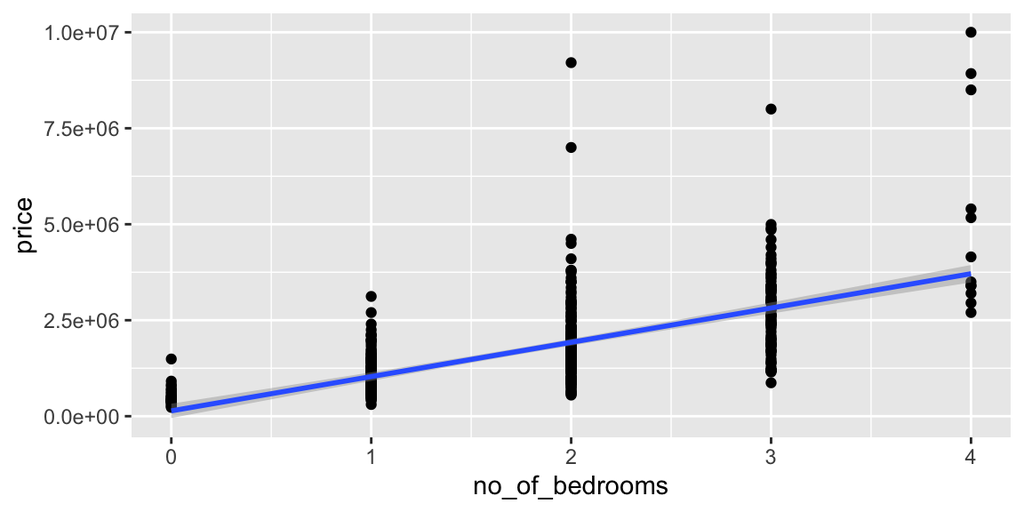

Price by Number of Bedrooms

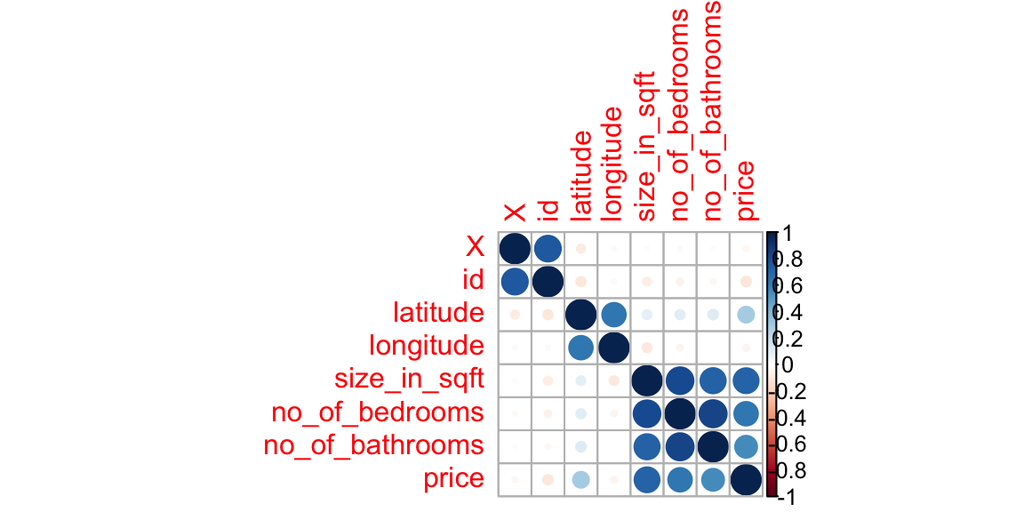

Correlation Plot for Quantitative Variables

We graph the size in sqft and the price and we can see an upward in the graph and there might be a relation between them

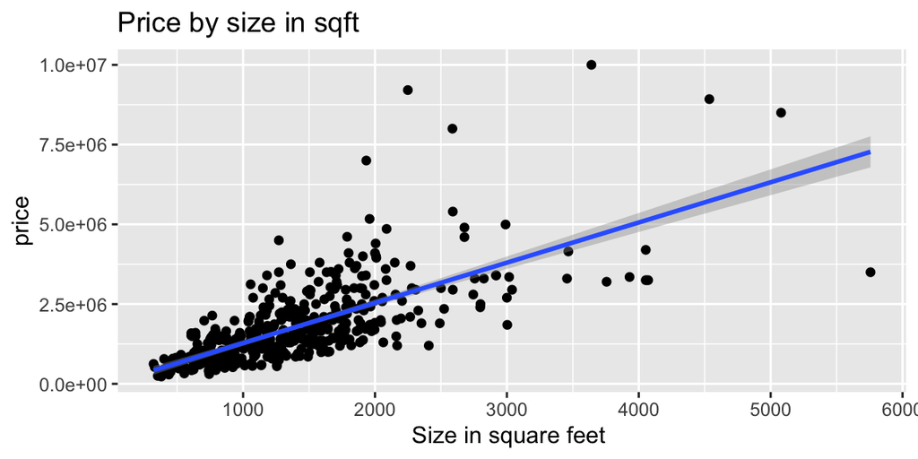

Price by size in sqft

```
## [1] 0.8206463
```

```
## [1] 0.8448697
```

Here we can see that the size in sqft the bedrooms and the bathrooms have pretty much very strong relation among them. So we can add one or two of them to avoid collinearity as they ar ehighly correlated.

Then we try to put a table for the security variable and price as security is very important measure for an apartment , intuitively. We can see that price differs a lot according to the security status of the apartment and we might add this to the model of best fit

Average Price by Security provided

| security | Mean_Price | SD_Price | N |
| --- | --- | --- | --- |
| FALSE | 1855908 | 1369992.8 | 325 |
| TRUE | 1461672 | 919071.6 | 175 |

## Feature Engineering

We convert the neighborhood and the quality to factor on both the test and the train data.

We create a table to see if there is any possible relation between the quality of the apartment with the price and we create a graph with the mean price of the rooms of each quality. we can see from the table that the price differs by the quality . but the price of medium and low is very close but still there is differenc eso we might add the varibale in our model.

Average Price by Room quality

| quality | Mean_Price | SD_Price | N |
| --- | --- | --- | --- |
| High | 1361497.8 | 760254.7 | 33 |
| Low | 1750358.4 | 1015323.9 | 149 |
| Medium | 1808159.3 | 1404227.4 | 293 |
| Ultra | 937574.7 | 406138.8 | 25 |

#More variable engineering:

1. Combine the variables like shared pool , shared gym and shared spa and create a new variable poolfacilities as they seem to be facilities regarding to pool. we have created such new variable combining kind of same variables and that helped us to work with less amount of variables.
2. AS we have seen that there are a lot of neighborhoods which don’t have a lot of apartments and seem to be sub areas. So we try to keep 6 major areas and put the others as ‘other’ neighbor hood. We have done that for both test and train data sets

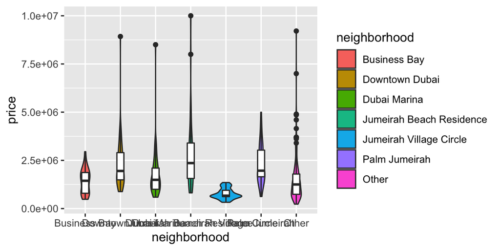

Price Distribution by Neighborhood

We plot all the new variables we have created combining some variables which might be important and we will look for relationship with price.

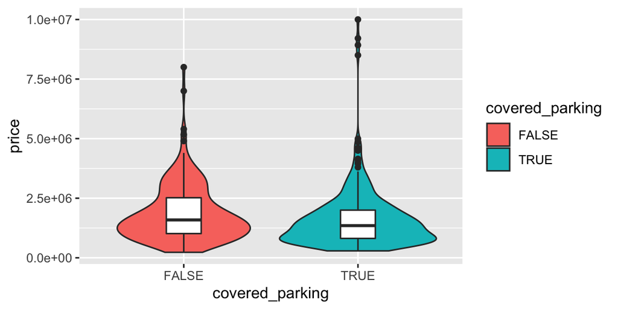

Price Distribution by Covered parking

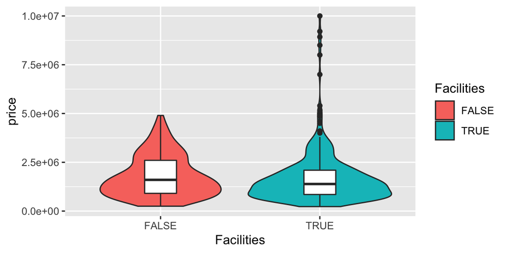

Price Distribution by Facilities

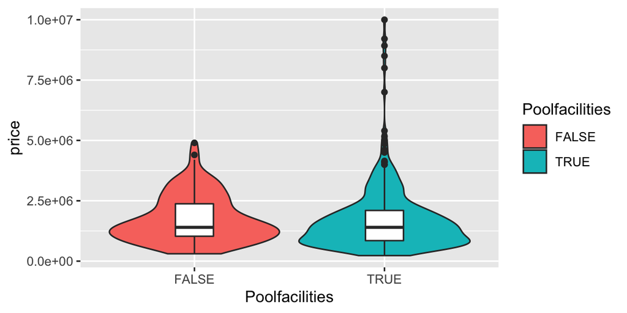

Price Distribution by Poolfacilities

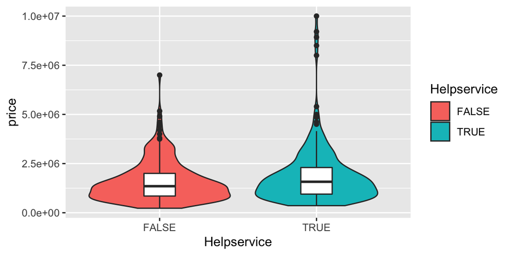

Price Distribution by Help Service

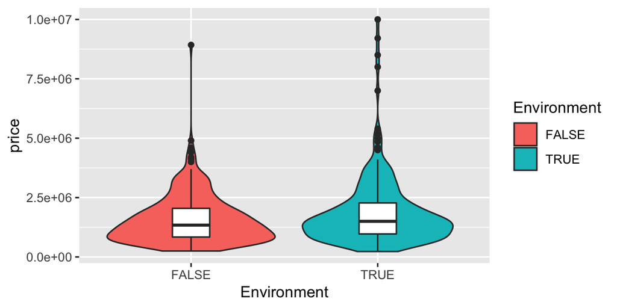

Price Distribution by Environment

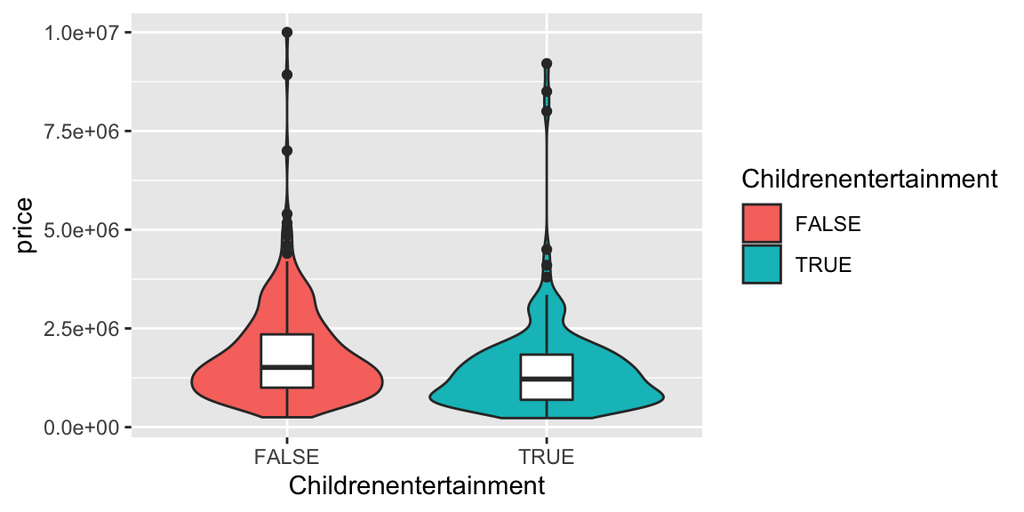

Price Distribution by Children Entertainment

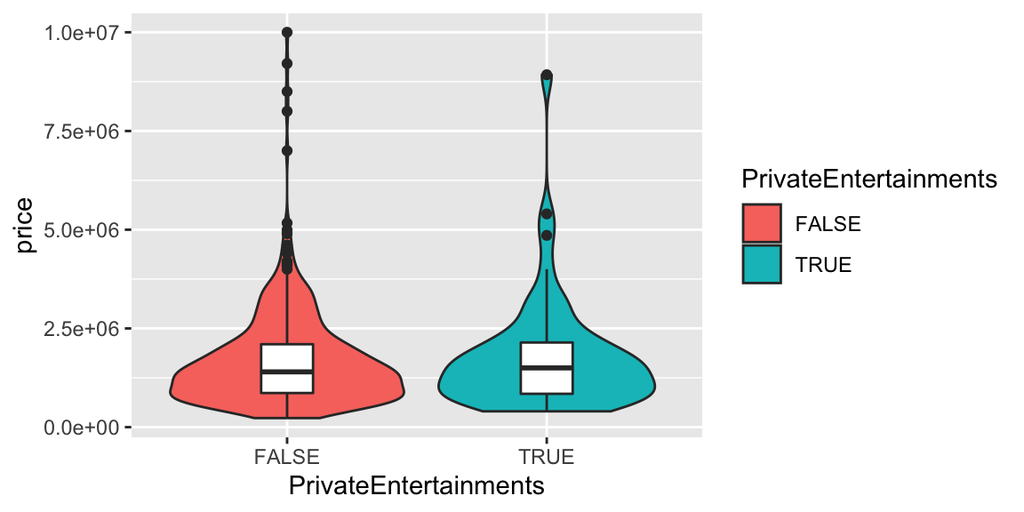

Price Distribution by PrivateEntertainments

Average Price by Unfurnished or furnished status

| unfurnished | Mean_Price | SD_Price | N |
| --- | --- | --- | --- |
| FALSE | 1665415 | 1151208 | 164 |
| TRUE | 1743556 | 1288377 | 336 |

We cannot fit a model when there are missing values in the data. We have already seen that there are no missing values in the data set.

We’ll perform 5 repeats of 5-fold cross validation.

We consider 8 models:

1. simple linear regression model using only no of bedrooms as explanatory variable.
2. multiple regression model with the four quantitative explanatory variables most highly correlated with price.
3. same variables as in (2), with interactions included.
4. multiple regression model with bedrooms, and two categorical variables: quality, and Neighborhood
5. same model as in (4), with interactions included.
6. multiple regression model with combination of categorical and quantitative variables mentioned so far.
7. model including almost all variables, and leaving out only those that we wouldn’t expect to have much relationship with price and have a multicollinearity ( latitude, longitude, id )
8. model including all variables in the dataset

Cross Validation Results

| Model | RMSPE |
| --- | --- |
| 1 | 951335.2 |
| 2 | 873836.8 |
| 3 | 891505.1 |
| 4 | 891391.2 |
| 5 | 920935.7 |
| 6 | 818616.9 |
| 7 | 804196.0 |
| 8 | 819389.0 |

We also consider predicting log(price), using the same 8 models.

Cross Validation Results for Log Model

| Model | RMSPE |
| --- | --- |
| 1 | 0.4348379 |
| 2 | 0.4140730 |
| 3 | 0.3975288 |
| 4 | 0.3691113 |
| 5 | 0.3809834 |
| 6 | 0.3537808 |
| 7 | 0.3458035 |
| 8 | 0.3182750 |

We see that model 7 was best at predicting price directly, while model 8 was best at predicting log(price). We can’t compare these directly using the R output from Train because RMSPE is computed on different scales.

Instead, we’ll convert the predictions for log(price) back to price, and calculate RMSPE ourselves for these two models. We partition the data into a training set, containing 80% of the data, and a test set, containing the remaining 20%, and repeat this procedure 10 times. This is not true cross-validation, since we aren’t dividing into distinct folds, and withholding each fold once, but it has the same effect of evaluating the model on data not used to train it.

Comparsion of MSPE for Log and Original Response Scales

| Model | RMSPE |
| --- | --- |
| Original | 766874.2 |
| Log of Exp. Vars | 779647.1 |

We see that the model that did not use the log transfrom performed better.

We’ll create residual plots for this model.

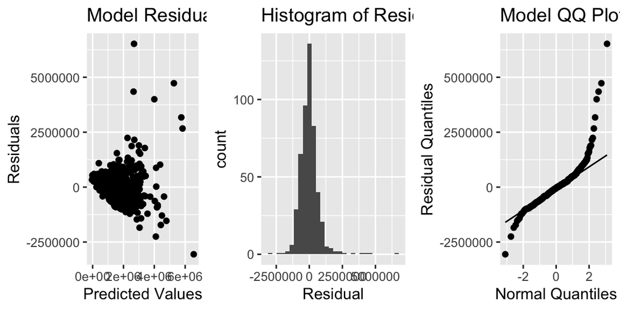

Plots for Model Check

We can see from the residual plot that there is a funnel shape in the residual plot and thus we should be concerned about the constant variance and we can see that the histogram is a bit right skewed and also there is a curvature in the normal qq plot so we can say that we should be concerned about the normality too but as we are doing prediction here we shouldn’t use the log transformation as we have already seen in the RMSPE that the log transformation is not better than the normal model so we are not going to transform the model . Also there we can see that there is a linear relation in the residual plot so we should not worry about the assumptions and use transformation. But we should keep in mind about the model assumptions.

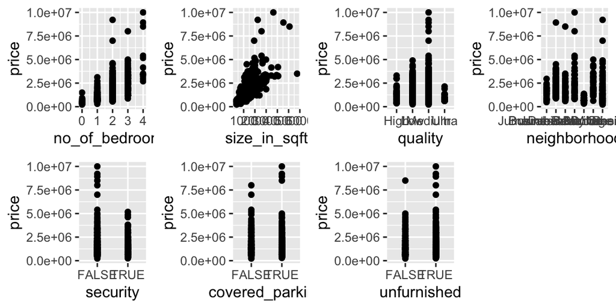

In conclusion we can say that this model could be the best fit to predict the prices of the apartments in the test data, We have included and analyzed all the possible factors or variables that could help to predict the price perfectly and put in the model or exempt it. We have also checked 8 possible models and checked which one works or perform better and we have came out with a model and this can predict the price better in the test data.